# Success, collaborations and the networks we keep

Data Science Week · University of Twente

Leto Peel

2026-06-16

[interactive chart not shown]

### Success, collaborations and the networks we keep

*what shapes a scientific career — and what we’re really counting*

Leto Peel

**Maastricht University**

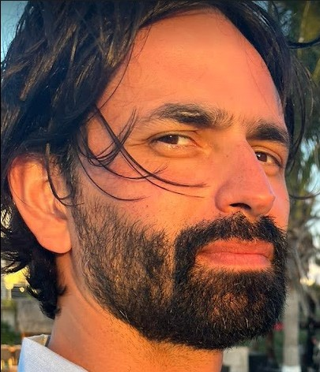

**MEng** Engineering Maths · Bristol

**BAE Systems** — anomaly detection, robotics

**EngD / Postdoc** · UCL

**Postdoc** BioFrontiers · Colorado

**Postdoc** Applied Maths · UCLouvain

**Now** Maastricht — School of Business & Economics

*(and publishes in physics journals)*

Who am I? = *an undisciplined scientist*

Before we start

A couple of questions for the room

[figure not shown]

Go to wooclap.com and enter code SPGSNYY

What is your discipline?

[interactive chart not shown]

How do you measure scientific success?

[interactive chart not shown]

What helps a scientific career succeed?

[interactive chart not shown]

Part 1

Science is something we can study as data

## Science as a network

[interactive chart not shown]

## The network has structure

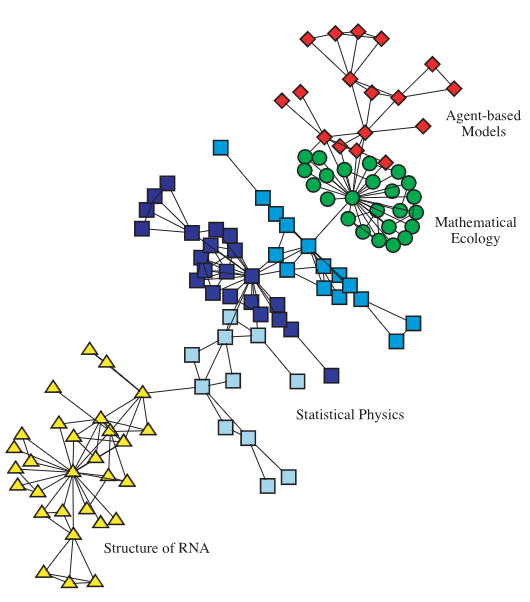

Newman · *PNAS* (2004) · coauthorship network

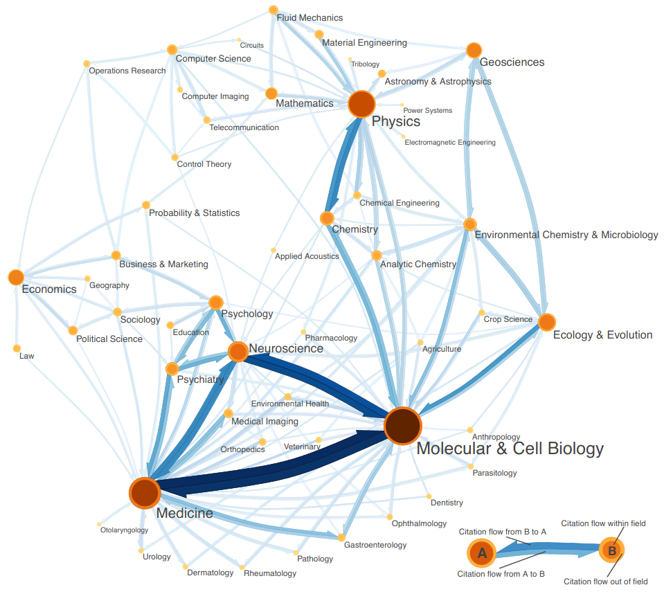

Rosvall & Bergstrom · *PNAS* (2008) · citation network

## Crossing these boundaries is hard

**Harder to fund** — interdisciplinary proposals have consistently lower success rates

**Lower productivity** — cognitive burden, difficulty framing work for reviewers, extra time building shared language across fields

Leahey, Beckman & Stanko · *Admin. Sci. Q.* (2017)

**Citations arrive late and score lower** — cross-discipline work takes longer to be noticed, and receives fewer citations in the short term

Rinia et al. · *Scientometrics* (2001) · Larivière & Gingras · *JASIST* (2010)

## …but it pays off

Uzzi, Mukherjee, Stringer & Jones · *Science* (2013) · 17.9 million papers

[interactive chart not shown]

**And it pays off later too** — interdisciplinary researchers eventually outperform peers in funding volume and value

Sun, Livan, Ma & Latora · *Comms. Physics* (2021)

## Science is built by teams now

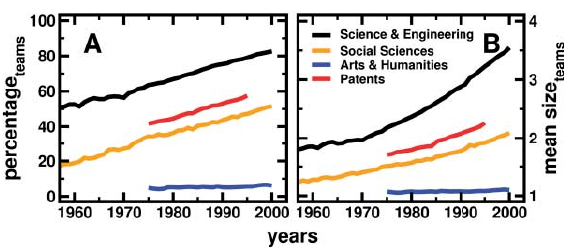

Wuchty, Jones & Uzzi · *Science* (2007) · 19.9 million papers across 5 decades

## Teams also produce more cited work

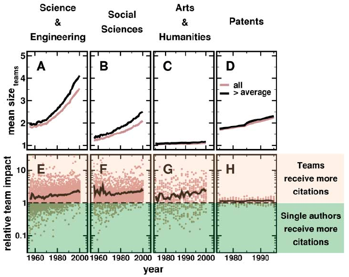

Wuchty, Jones & Uzzi · *Science* (2007)

## Who you work with early shapes everything

Sekara, Deville, Ahnert, Barabási, Sinatra & Lehmann · *PNAS* (2018)

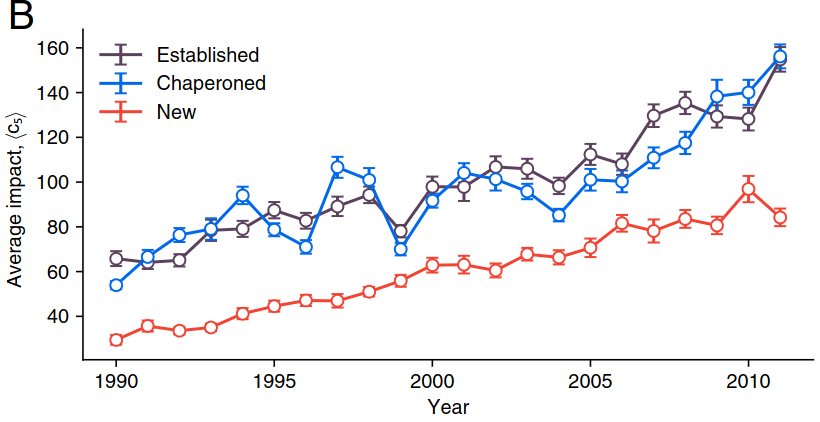

Papers by new PIs receive half the citations of papers by chaperoned PIs — in the same journal.

Mentors are collaborators. Who you publish with early shapes what you publish later.

## Your collaboration network is social capital

Li, Zhang, Zheng, Cranmer & Clauset · *Nature Communications* (2022)

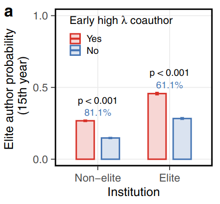

Productive senior collaborator

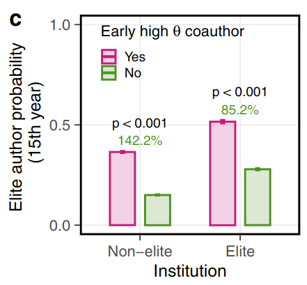

High-impact senior collaborator

Who you collaborate with early shapes where you end up.

Part 2

35,000 careers, one network at a time

## What we did

[interactive chart not shown]

She, Bachmann, Karimi & Peel · arXiv 2602.22031 (2026)

## Selecting focal authors

[interactive chart not shown]

She, Bachmann, Karimi & Peel · arXiv 2602.22031 (2026)

## Building a collaboration network

[interactive chart not shown]

## Controlling for productivity

More papers → more collaborators · more collaborators → lower clustering.

We isolate **network shape** from **raw output** using regression residuals.

[interactive chart not shown]

## How we find the clusters

[interactive chart not shown]

## Ten ways a career network grows

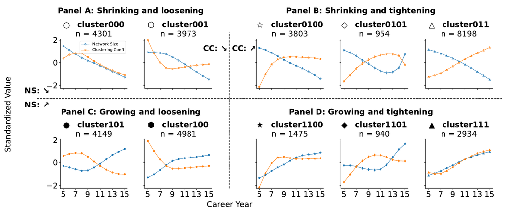

## Moving around is linked to better outcomes

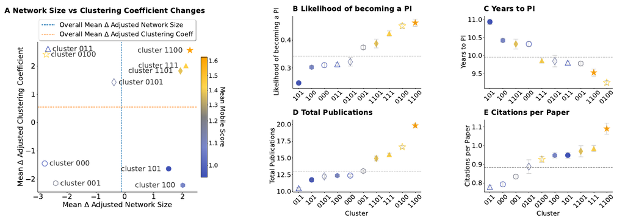

Researchers who are **mobile** tend to do better —

## A caution before we go further

These are patterns that *accompany* success.

Not a recipe that *causes* it.

Part 3

What were we measuring all along?

## We all said it

Everyone today — including us — called citations and job titles “success.”

Should we have?

## What the numbers actually count

**A citation**

At best, someone read it — or at least the reference list. Not that it’s right, good, or influential.

**A publication count**

Says nothing about quality, splits one finding into three papers, and ignores the null results that never got written up.

**Last authorship**

Conventions differ by field — and even within one, it’s a single snapshot, not the moment someone actually started supervising PhDs.

## When a measure becomes a target

…it stops being a good measure.

This week you’re **predicting citations**. So — what gets gamed, and what gets lost?

## Three things to take with you

**Crossing boundaries costs you**

Slower funding, fewer papers, late citations — but it pays off long-term.

**The sweet spot is loose-then-tight**

**The ruler matters**

Citations and titles are proxies. What we count shapes what we find.

The networks we keep shape the careers we build — and the science we get.

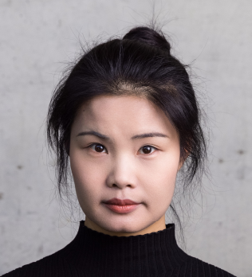

**Mingrong She**  
Maastricht University

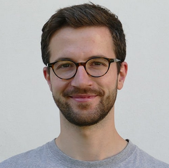

**Jan Bachmann**  
CSH Vienna

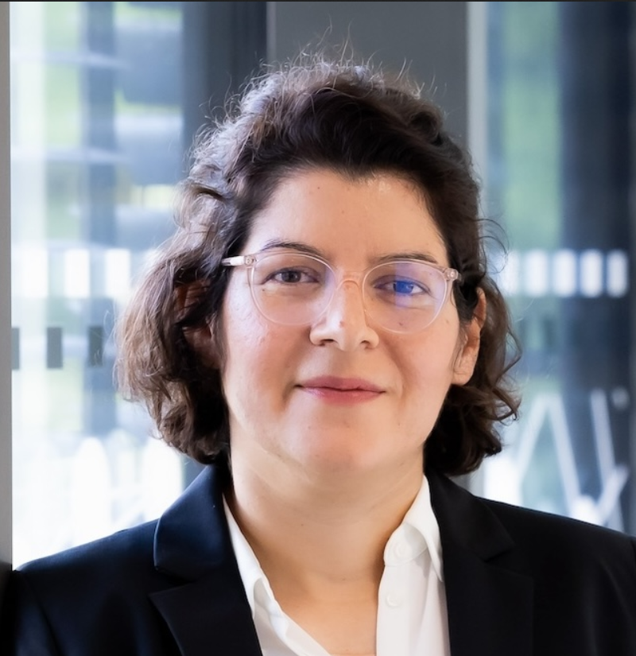

**Fariba Karimi**  
TU Graz

She, Bachmann, Karimi & Peel · *Academic collaborations and successful careers in physics* (2026) She, Bachmann, Karimi & Peel · *Gender differences in collaboration and career progression* · *Royal Society Open Science* (2025)

Science is a human endeavour.

It’s not enough to be right — you have to convince your peers.

Thank you · let’s discuss